# Pruning & Rooting Phylogenetic Trees with ggTree

Antone Jung

2025-03-30

# Goals

## Outputs

# Before you start

## Set my seed

```r
# Any number can be chosen
set.seed(10202005)
```

## Load Packages

```r
pacman::p_load(tidyverse, phyloseq, ggtree, phytools, tidytree, phylobase,
               install = FALSE)
```

## 1. Load Data files

```r
# Preprocessed phyloseq object
load("data/03_PreProcessing/raw_preprocessed_physeq.RData")

# Inspect the phyloseq object
raw_preprocessed_physeq
```

```
## phyloseq-class experiment-level object
## otu_table()   OTU Table:         [ 9360 taxa and 36 samples ]
## sample_data() Sample Data:       [ 36 samples by 9 sample variables ]
## tax_table()   Taxonomy Table:    [ 9360 taxa by 9 taxonomic ranks ]
```

```r
# Load in the tree!
unrooted_tree <- read.tree("data/04_PhylogeneticTree/ASVs_unrooted.tree")

# Take a look at the tree
unrooted_tree
```

```
##
## Phylogenetic tree with 9360 tips and 9358 internal nodes.
##
## Tip labels:
##   ASV_2420, ASV_8817, ASV_8865, ASV_8742, ASV_9565, ASV_4150, ...
## Node labels:
##   , 0.941, 0.878, 0.996, 0.929, 0.990, ...
##
## Unrooted; includes branch length(s).
```

```r
str(unrooted_tree)
```

```
## List of 5
##  $ edge       : int [1:18717, 1:2] 9361 9362 9363 9364 9365 9365 9366 9367 9368 9369 ...
##  $ edge.length: num [1:18717] 0.04773 0.07084 0.18019 0.03227 0.00891 ...
##  $ Nnode      : int 9358
##  $ node.label : chr [1:9358] "" "0.941" "0.878" "0.996" ...
##  $ tip.label  : chr [1:9360] "ASV_2420" "ASV_8817" "ASV_8865" "ASV_8742" ...
##  - attr(*, "class")= chr "phylo"
##  - attr(*, "order")= chr "cladewise"
```

# 2. Merge Unrooted Tree & `raw_preprocessed_physeq`

Now that we’ve loaded in both our `raw_preprocessed_physeq` and the unrooted tree, let’s merge them into one phyloseq object that can be used to plot the tree with ggtree.

```r
# Intuition check
stopifnot(ntaxa(raw_preprocessed_physeq) == ntaxa(unrooted_tree))
# No news is good news!

# Merge the tree with the phyloseq object
unrooted_physeq <-
  merge_phyloseq(raw_preprocessed_physeq, unrooted_tree)

# Let's take a look!
unrooted_physeq
```

```
## phyloseq-class experiment-level object
## otu_table()   OTU Table:         [ 9360 taxa and 36 samples ]
## sample_data() Sample Data:       [ 36 samples by 9 sample variables ]
## tax_table()   Taxonomy Table:    [ 9360 taxa by 9 taxonomic ranks ]
## phy_tree()    Phylogenetic Tree: [ 9360 tips and 9358 internal nodes ]
```

# 3. Visualize and inspect tree with [ggtree](https://besjournals.onlinelibrary.wiley.com/doi/full/10.1111/2041-210X.12628).

Now, let’s take a look

## Kingdom Level Tree

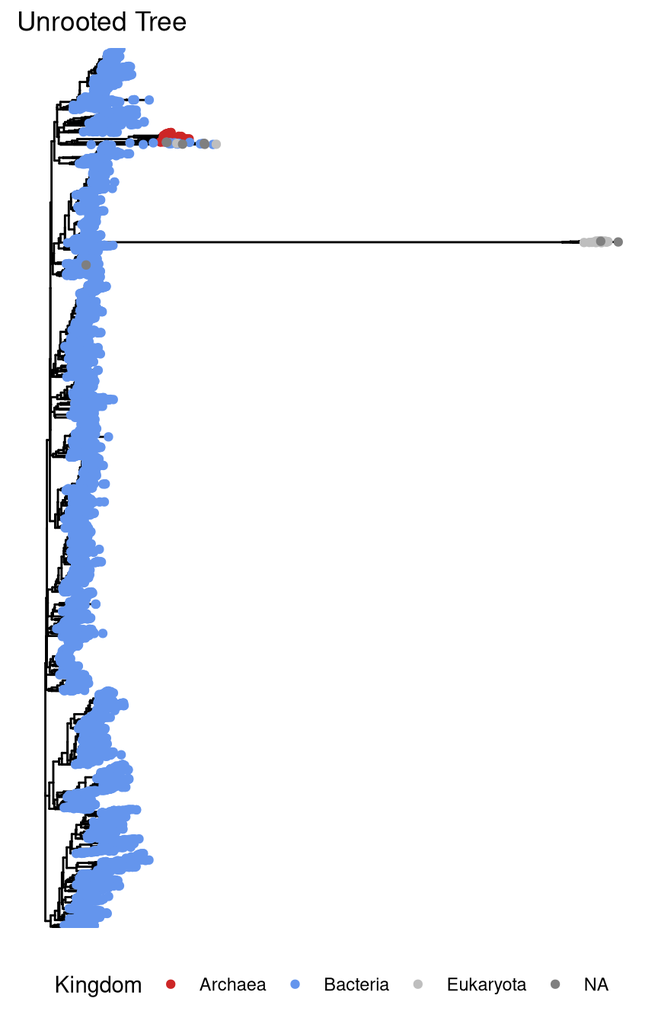

```r
# Make a basic tree with the domains
kingdom_tree <-
  ggtree(unrooted_physeq) +
  # color tips by kingdom
  geom_tippoint(mapping = aes(color = Kingdom)) +
  # add a title
  labs(title = "Unrooted Tree") +
  scale_color_manual(values = c("firebrick3", "cornflowerblue", "grey")) +
  # Move the legend to the bottom of the tree
  theme(legend.position = "bottom")

# Look at it
kingdom_tree
```

```r
# Check if tree is rooted
is.rooted(unrooted_tree) # should be TRUE
```

```
## [1] FALSE
```

In the above unrooted tree, we can see all of the Archaea fall within the bacteria. Huh?! This **does not make evolutionary sense!** Therefore, we will need to **root** the tree to fix this. *But what does it mean to root the tree, you ask???* We will get to this in a minute!

### Do you expect to have Archeaea?

Regions of the 16S rRNA gene are better/worse for amplifying archaea that might be present in our samples. If you’re wondering more, please check out this [2021 Annual Reviews of Microbiology paper by Tahon et al](https://www.annualreviews.org/content/journals/10.1146/annurev-micro-040921-050212), specifically Figure 2 and the tables. What I’ve learned about archaea over the years is:

- Better regions for Archaeal Detection:
  - V4 or V4–V5 (e.g., 515F-Y / 806R-B or 926R): Improved archaeal coverage (including Thaumarchaeota and Euryarchaeota) compared to older V4-only approaches due to primer updates by [Parada et al., 2015](https://journals.asm.org/doi/10.1128/msystems.00009-15) and [Aprill et al., 2016](https://www.int-res.com/abstracts/ame/v75/n2/p129-137/), captures both Bacteria and Archaea reasonably well and provides the best balance for broad community surveys
- Caution with these regions
  - [Original V4 primers (515F/805R)](https://www.pnas.org/doi/10.1073/pnas.1000080107?url_ver=Z39.88-2003&rfr_id=ori%3Arid%3Acrossref.org&rfr_dat=cr_pub++0pubmed): Common and well-supported for Bacteria BUT original 515F underrepresents Thaumarchaeota, a key archaeal group in soils, oceans, and freshwater.
  - V3–V4 (e.g., 341F / 805R): Popular due to high taxonomic resolution for Bacteria but biased against Archaea in most environmental samples—specifically, some archaeal groups lack primer binding sites in this region.
  - V6–V8 or V7–V9: Rarely used for Archaea (less common for bacteria, too), region is less conserved across archaeal groups, Low coverage unless paired with archaeal-specific primers.

In summary:

### Summary: Hypervariable Region Selection for Archaea

| Region | Coverage of Archaea | Notes |
| --- | --- | --- |
| V4–V5 | ✅ Good | Best for mixed Bacteria + Archaea |
| V3–V5 | ✅ Good | Broad, longer amplicon (good with 2×300 bp) |
| V4 only | ⚠️ Moderate | Use [515F-Y](https://journals.asm.org/doi/10.1128/msystems.00009-15) instead of original 515F |
| V3–V4 | ❌ Poor | Biased toward Bacteria |
| V6–V8 | ❌ Poor | Not recommended for general use |

*Ok, now that we’ve considered the archaea, let’s think about the branches in our tree!*

# 4. Long Branches?

Now, let’s think about the quality of our tree. Evaluate that kingdom tree above…

INTERPRETATION #1: There’s a very strange branch with primarily eukaryotes and NA, which is weird b/c I didn’t think 16S primers would amplify eukaryotic DNA.

Before we move onto rooting, this is where we need to assess if we have any long and wonky branches!

## 4a. Evaluate Long Branches

This part will get a little manual, however, this is an important step along the way to ensure that we are feeling certain that our data quality is good.

### Kingdom Tree with Node Labels

Let’s put labels on our tree so we have a bit more flexibility

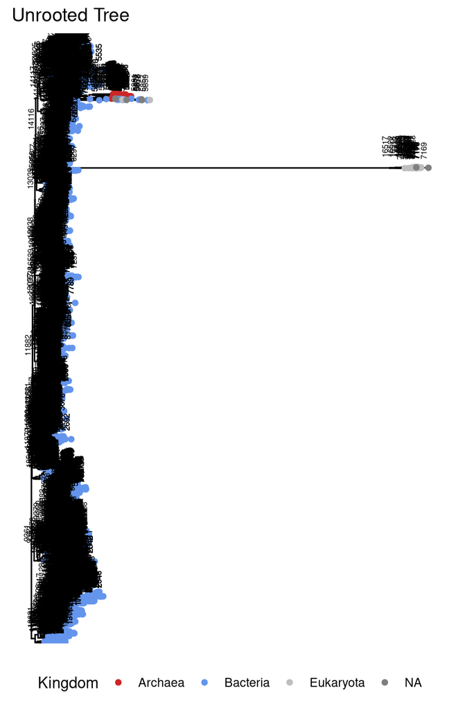

```r
kingdom_node_tree <-
  kingdom_tree +
  # Add the node label
  geom_text(aes(label=node), hjust= -0.5, vjust = -0.3, size = 2, angle = 90)

# Plot the tree
kingdom_node_tree
```

In the phylogeny above, it looks like **node #7169** is quite long. Otherwise, things look mostly ok.

### Evaluate node #7169

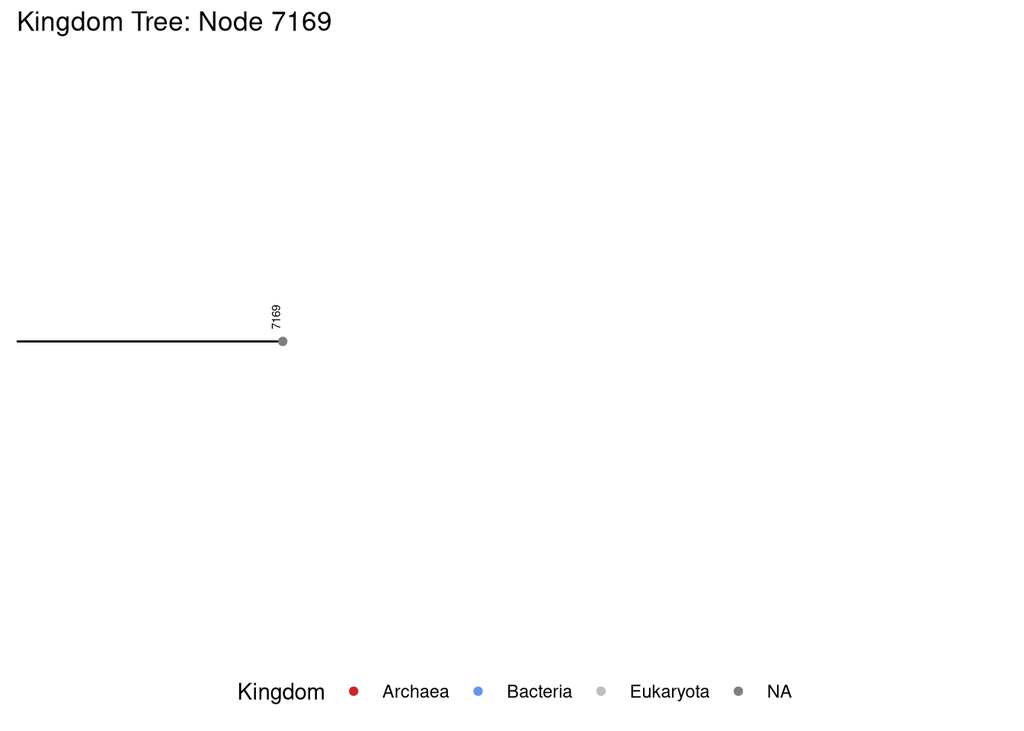

```r
# View a specific clade
# Zoom in on node that looks potentially suspicious
viewClade(kingdom_node_tree +
          labs(title = "Kingdom Tree: Node 7169"),
          node = 7169)
```

```r
# This plot is too zoomed in! Let's try to zoom out by looking at ancestors
# Lets see its ancestors, which will tell us each node as it steps up.
# It's ideal to look a couple nodes up but not too far!
tidytree::ancestor(unrooted_tree, 7169) # The input is the TREE, not phyloseq!!
```

```
##  [1] 16534 16533 16532 16524 16522 16517 16515 15700 15624 15477 15350 14116
## [13] 13039 13038 13037 11882 11881 11880 11879  9361
```

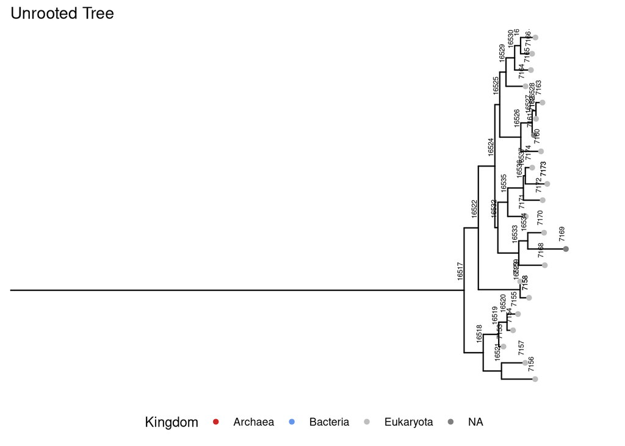

```r
# Let's evaluate 16155!!
viewClade(kingdom_node_tree, 16517) # even more zoomed out
```

In the subtree above, 7169 is one of the end points of a tree rooted in 16517 (the branch point for this long cluster)

```r
# Or if there are two nodes that we can see we can find its MRCA
## create tibble of tree to identify offspring
tree_tib <- as_tibble(unrooted_physeq@phy_tree)

# Inspect
head(tree_tib)
```

```
## # A tibble: 6 × 4
##   parent  node branch.length label
##    <int> <int>         <dbl> <chr>
## 1   9365     1       0.00891 ASV_2420
## 2   9369     2       0.00054 ASV_8817
## 3   9369     3       0.00439 ASV_8865
## 4   9368     4       0.0134  ASV_8742
## 5   9367     5       0.00054 ASV_9565
## 6   9366     6       0.0100  ASV_4150
```

```r
str(tree_tib)
```

```
## tbl_tree [18,718 × 4] (S3: tbl_tree/tbl_df/tbl/data.frame)
##  $ parent       : int [1:18718] 9365 9369 9369 9368 9367 9366 9371 9371 9370 9373 ...
##  $ node         : int [1:18718] 1 2 3 4 5 6 7 8 9 10 ...
##  $ branch.length: num [1:18718] 0.00891 0.00054 0.00439 0.0134 0.00054 ...
##  $ label        : chr [1:18718] "ASV_2420" "ASV_8817" "ASV_8865" "ASV_8742" ...
```

```r
# lets look at the long branch
mrca_node_16517 <- tidytree::MRCA(unrooted_tree, .node1 = 16517)

# Inspect
mrca_node_16517
```

```
## [1] 16517
```

```r
## create dataframe to view ASVs and taxa info and to pull the ASVs
node_16517 <-
  offspring(tree_tib, mrca_node_16517, tiponly = TRUE) %>%
  as.data.frame() %>%
  pull(label)

# Inspect
node_16517
```

```
##  [1] "ASV_8358" "ASV_9231" "ASV_9340" "ASV_9249" "ASV_9580" "ASV_6908"
##  [7] "ASV_8989" "ASV_9381" "ASV_9196" "ASV_6250" "ASV_8295" "ASV_6962"
## [13] "ASV_9285" "ASV_8356" "ASV_8361" "ASV_8796" "ASV_9425" "ASV_9282"
## [19] "ASV_9284" "ASV_9406" "ASV_7814" "ASV_9287"
```

```r
# Now, let's pull out the taxonomy information, including the ASV sequence!
node_16517_df <-
  unrooted_physeq %>%
  tax_table() %>%
  as.data.frame() %>%
  filter(ASV %in% node_16517)

# Take a look:
glimpse(node_16517_df)
```

```
## Rows: 22
## Columns: 9
## $ Kingdom <chr> "Eukaryota", "Eukaryota", "Eukaryota", "Eukaryota", "Eukaryota…
## $ Phylum  <chr> NA, NA, NA, NA, NA, NA, NA, NA, NA, NA, NA, NA, NA, NA, NA, NA…
## $ Class   <chr> NA, NA, NA, NA, NA, NA, NA, NA, NA, NA, NA, NA, NA, NA, NA, NA…
## $ Order   <chr> NA, NA, NA, NA, NA, NA, NA, NA, NA, NA, NA, NA, NA, NA, NA, NA…
## $ Family  <chr> NA, NA, NA, NA, NA, NA, NA, NA, NA, NA, NA, NA, NA, NA, NA, NA…
## $ Genus   <chr> NA, NA, NA, NA, NA, NA, NA, NA, NA, NA, NA, NA, NA, NA, NA, NA…
## $ Species <chr> NA, NA, NA, NA, NA, NA, NA, NA, NA, NA, NA, NA, NA, NA, NA, NA…
## $ ASV     <chr> "ASV_8358", "ASV_9231", "ASV_9340", "ASV_9249", "ASV_9580", "A…
## $ ASVseqs <chr> "TCCTGTTTGATCCCCACGCTTTCGTGCCTCAGCGTCAATATATGCGTAGTAAGCTGCCTTC…
```

```r
# look at counts of the ASVs
unrooted_physeq %>%
  subset_taxa(., ASV %in% node_16517_df$ASV) %>%
  otu_table() %>%
  data.frame() %>%
  colSums()
```

```
## SRR12183139 SRR12183147 SRR12183158 SRR12183176 SRR12183187 SRR12183204
##          16           5          18           0           0           0
## SRR12183215 SRR12183228 SRR12183239 SRR12183259 SRR12183269 SRR12183285
##           0           2           0           2           3           0
## SRR12183296 SRR12183309 SRR12183310 SRR12183321 SRR12183332 SRR12183337
##           2           0           2           0           0           0
## SRR12183348 SRR12183359 SRR12183366 SRR12183377 SRR12183388 SRR12183423
##           0           0           0           0           0           0
## SRR12183485 SRR12183496 SRR12183504 SRR12183505 SRR12183516 SRR12183527
##           0           0           0           0           2           3
## SRR12183532 SRR12183543 SRR12183554 SRR12183559 SRR12183560 SRR12183561
##           0           9           7           9           0           0
```

```r
# Lets BLAST our sequences to investigate if they are real or not
node_16517_df
```

```
##            Kingdom Phylum Class Order Family Genus Species      ASV
## ASV_8358 Eukaryota   <NA>  <NA>  <NA>   <NA>  <NA>    <NA> ASV_8358
## ASV_9231 Eukaryota   <NA>  <NA>  <NA>   <NA>  <NA>    <NA> ASV_9231
## ASV_9340 Eukaryota   <NA>  <NA>  <NA>   <NA>  <NA>    <NA> ASV_9340
## ASV_9249 Eukaryota   <NA>  <NA>  <NA>   <NA>  <NA>    <NA> ASV_9249
## ASV_9580 Eukaryota   <NA>  <NA>  <NA>   <NA>  <NA>    <NA> ASV_9580
## ASV_6908 Eukaryota   <NA>  <NA>  <NA>   <NA>  <NA>    <NA> ASV_6908
## ASV_8989 Eukaryota   <NA>  <NA>  <NA>   <NA>  <NA>    <NA> ASV_8989
## ASV_9381 Eukaryota   <NA>  <NA>  <NA>   <NA>  <NA>    <NA> ASV_9381
## ASV_9196      <NA>   <NA>  <NA>  <NA>   <NA>  <NA>    <NA> ASV_9196
## ASV_6250 Eukaryota   <NA>  <NA>  <NA>   <NA>  <NA>    <NA> ASV_6250
## ASV_8295 Eukaryota   <NA>  <NA>  <NA>   <NA>  <NA>    <NA> ASV_8295
## ASV_6962 Eukaryota   <NA>  <NA>  <NA>   <NA>  <NA>    <NA> ASV_6962
## ASV_9285 Eukaryota   <NA>  <NA>  <NA>   <NA>  <NA>    <NA> ASV_9285
## ASV_8356 Eukaryota   <NA>  <NA>  <NA>   <NA>  <NA>    <NA> ASV_8356
## ASV_8361 Eukaryota   <NA>  <NA>  <NA>   <NA>  <NA>    <NA> ASV_8361
## ASV_8796 Eukaryota   <NA>  <NA>  <NA>   <NA>  <NA>    <NA> ASV_8796
## ASV_9425      <NA>   <NA>  <NA>  <NA>   <NA>  <NA>    <NA> ASV_9425
## ASV_9282 Eukaryota   <NA>  <NA>  <NA>   <NA>  <NA>    <NA> ASV_9282
## ASV_9284 Eukaryota   <NA>  <NA>  <NA>   <NA>  <NA>    <NA> ASV_9284
## ASV_9406 Eukaryota   <NA>  <NA>  <NA>   <NA>  <NA>    <NA> ASV_9406
## ASV_7814 Eukaryota   <NA>  <NA>  <NA>   <NA>  <NA>    <NA> ASV_7814
## ASV_9287 Eukaryota   <NA>  <NA>  <NA>   <NA>  <NA>    <NA> ASV_9287
##                                                                                                                                                                                                                                                                ASVseqs
## ASV_8358 TCCTGTTTGATCCCCACGCTTTCGTGCCTCAGCGTCAATATATGCGTAGTAAGCTGCCTT…
## ASV_9231 TCCTGTTTGATCCCCACGCTTTCGAGCCTCAGTGTCAATAATTGTGTAGCAAGCTGCCTT…
## ASV_9340 TCCTGTTTGATCCCCACGCTTTCGAGCCTCAGTGTCAATGTCTCCGTAGTAAGCTGCCTT…
## ASV_9249 TCCTGTTCGCTCCCCACGCTTTCGTGCCTCAGTGTCAGAACAAGCGTAGCCACCTGCCTT…
## ASV_9580 TCCTGTTTGATCCCCACACTTTCGTGCCTCAGTGTCAGTTAAAGCTTAGTAAACTGCCTT…
## ASV_6908 TCCTGTTTGCTCCCCATGCTTTCGAGCCTCAGCGTCAATATGTGTCCAGACGGCCGCCTT…
## ASV_8989 TCCTGTTTGCTCCCCATGCTTTCGAGCCTCAGCGTCAATATGTGTCCAGTCAGCCGCCTT…
## ASV_9381 TCCTGTTTGCTCCCCACGCTTTCGTGCATGAGCGTCAGTATTGGCCCAGAAGGCTGCCTT…
## ASV_9196 TCCTGTTTGCTCCCCACGCTTTCGTGCATGAGCGTCAGTACAGGTCCAGGAGATTGCCTT…
## ASV_6250 TCCTGTTTGCTCCCCACGCTTTCGTGCATGAGCGTCAGTACAGGCCCAGGGGATTGCCTT…
## ASV_8295 TCCTGTTTGCTCCCCACGCTTTCGTGCATGAGCGTCAGTGCAGGCCCAGGGGATTGCCTT…
## ASV_6962 TCCTGTTTGCTCCCCACGCTTTCGTGCCTCAGTGTCAGTGTTGGCCCAGGATGCCGCCTT…
## ASV_9285 TCCTGTTTGCTCCCCACGCTTTCGTGCCTCAGTGTCAGTATTTGTCCAGAAAGTCGCCTT…
## ASV_8356 TCCTGTTTGCTCCCCACGCTTTCGCACCTCAGTGTCAGTATCAGTCCAGGTGGTCGCCTT…
## ASV_8361 TCCTGTTTGCTCCCCACGCTTTCGCACCTCAGTGTCAGTATGAGTCCAGGGTGTCGCCTT…
## ASV_8796 TCCTGTTCGCTCCCCACGCTTTCGCTCCTCAGCGTCAGTTACGGCCCAGAGATCTGCCTT…
## ASV_9425 TCCCGTTCGCTCCCCACGCCTTCGCGTCTCAGTGTCAGGAGCGGCCCAGGGGGCCGCCTT…
## ASV_9282 TCCTGTTTGCTCCCCACGCTTTCGCGTCTCAGCGTCAGTCACGTCCCAGCGAGCTGCCTT…
## ASV_9284 TCCTGTTTGCTCCCCACGCTTTCGCACCTCAGCGTCAGTATTGGCCCAGGTCGCCGCCTT…
## ASV_9406 TCCTGTTTGCTCCCCACGCTTTCGCACCTCAGCGTCAGTATCAGTCCAGCGAGTCGCCTT…
## ASV_7814 TCCTGTTTGCTCCCCACGCTTTCGAGCCTCAGCGTCAGTAATGATCCAGTAAGTCGCCTT…
## ASV_9287 TCCTGTTTGCTCCCCACGCTTTCGCACCTCAGCGTCAGTAATGGACCAGTAAGCCGCCTT…
```

Interesting! We can already conclude a few things:

- There are VERY FEW counts!
- Mostly Eukaryotic

Both of these conclusions make us skeptical of these ASVs!

# BLAST

## What to look for with BLAST Results?

If you’re identifying a sequence (like 16S rRNA or a gene):

- % Identity ≥ 97% for species-level 16S match (lower for genus)
- E-value ≤ 1e-5 (lower is better—e.g. 1e-20, 1e-50, etc.)
- High query coverage (ideally >90%)
- Long alignment length, especially for full genes or 16S sequences

### Most Important Values in BLAST Output

| Field | What It Means | Why It Matters | Good Values |
| --- | --- | --- | --- |
| **% Identity** | % of exact matches in aligned region | Measures sequence similarity | ≥ 97% for species (16S); lower for genus |
| **E-value** | Expected number of hits this good by chance | Lower = more statistically significant match | ≤ 1e-5 (e.g., 1e-20, 1e-50, etc.) |
| **Bit Score** | Normalized alignment score | Higher = better alignment | > 200 for strong alignments |
| **Alignment Length** | Number of bases or amino acids in the aligned region | Longer alignments are generally more reliable | As long as possible (e.g., >250 bp for 16S) |
| **Query Coverage** | % of your sequence aligned with the hit | High coverage increases confidence in identification | > 90% (ideally near 100%) |
| **Accession & Description** | ID and description of the matched sequence | Tells you what the hit is and where it comes from | Use top hit + trusted source |

## 4b. Prune your tree

```r
# Function from Joey McMurdie: https://github.com/joey711/phyloseq/issues/652
pop_taxa = function(physeq, badTaxa){
  allTaxa <-  taxa_names(physeq)
  allTaxa <- allTaxa[!(allTaxa %in% badTaxa)]
  return(prune_taxa(allTaxa, physeq))}

# Let's use the pop_taxa function :)
# Recreate a phyloseq object without your unwanted ASV or node
# Lets use the example ASVs above from node_3315_df
unrooted_physeq_rm16517 <-
  unrooted_physeq %>%
  pop_taxa(., node_16517_df$ASV)

# Check it
unrooted_physeq_rm16517
```

```
## phyloseq-class experiment-level object
## otu_table()   OTU Table:         [ 9338 taxa and 36 samples ]
## sample_data() Sample Data:       [ 36 samples by 9 sample variables ]
## tax_table()   Taxonomy Table:    [ 9338 taxa by 9 taxonomic ranks ]
## phy_tree()    Phylogenetic Tree: [ 9338 tips and 9336 internal nodes ]
```

```r
# Intuition Check: How many differ???
ntaxa(unrooted_physeq) - ntaxa(unrooted_physeq_rm16517)
```

```
## [1] 22
```

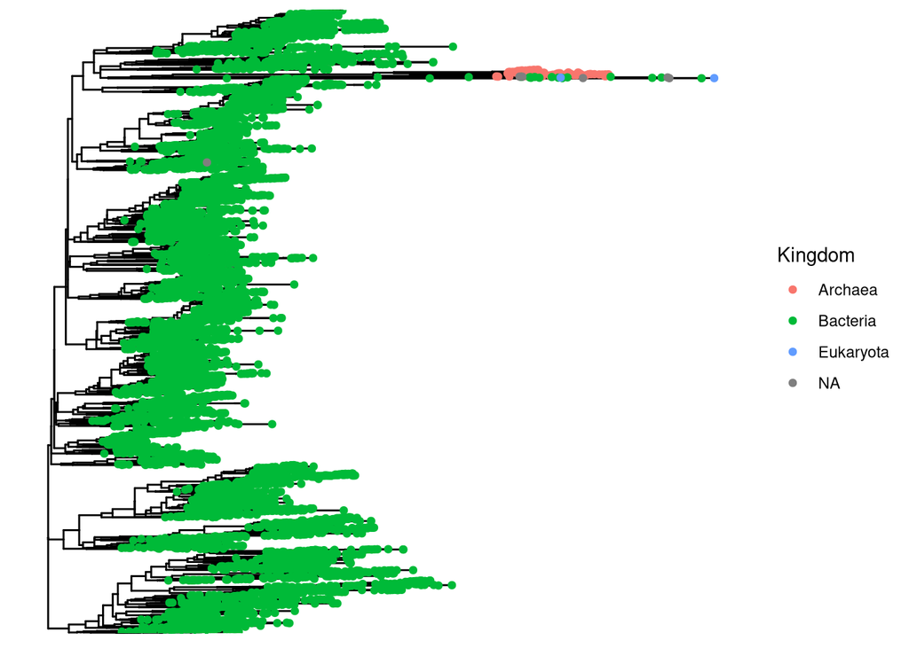

```r
# Visually inspect
ggtree(unrooted_physeq_rm16517) +
  geom_tippoint(mapping = aes(color = Kingdom))
```

# 5. Root the Tree

Now that we’ve pruned the trees of potentially contaminating ASVs, it’s time to root!

*What does it mean to root a tree, you ask?* **Rooting a tree** means designating a specific node in a phylogenetic tree as the common ancestor of all other nodes. This establishes a direction of evolution — from the root (the oldest ancestor) to the tips (the current taxa or sequences). A tree without a root is called **unrooted**, and it only shows relationships (like how closely related things are), not the direction of descent.

## Why do we root trees in microbial community analyses?

In microbial ecology, rooted trees are especially useful for:

1. **Calculating Phylogenetic Diversity Metrics**: Metrics like Faith’s Phylogenetic Diversity and the UniFrac distances require a rooted tree to calculate how much evolutionary history is shared between communities. Without a root, the distances between taxa don’t make biological sense in terms of lineage or shared ancestry.
2. **Comparing Community Structure:** Rooting allows you to identify lineages that dominate or are lost between samples, trace evolutionary shifts in microbial composition, interpret ecological or functional patterns across a gradient (*e.g.,* salinity, pH, antibiotic exposure).
3. **Biological Interpretation** Rooted trees are required for the following interpretations, which microbial community ecologists often want to know:
   - *Are these microbes derived from a common ancestor?*
   - *Do the samples diverge from a known lineage (e.g., Proteobacteria)*?
   - *What’s the evolutionary placement of unknown organisms?*

## Methods of Rooting Trees

So, **how do we root a tree**? There are two different types of methods to root a tree:

1. **Outgroup rooting:** Choose a known lineage outside your group of interest (*e.g.,* Archaea as outgroup to Bacteria). *This is always preferred when we have a known outgroup!*
   - *Pros:*
     - Biologically meaningful — places the root based on known evolutionary relationships.
     - More accurate if your outgroup is correctly chosen and aligns well.
     - **Best for:** Hypothesis-driven studies, evolutionary interpretations, or when your dataset includes taxa from multiple domains/phyla.
   - *Cons:*
     - Requires a reliable outgroup — too distant, and it can distort the tree (long-branch attraction).
     - Not always available or appropriate (e.g., if you’re only analyzing a subset of taxa without known outgroups).
2. **Midpoint rooting:** Places the root at the midpoint of the longest path in the tree (useful when no clear outgroup exists).
   - *Pros:*
     - Simple and automatic — no need for prior biological knowledge.
     - Works well for diverse microbial datasets where outgroup info is unclear or unavailable.
     - **Best for**: Exploratory analyses, diversity metrics (like UniFrac), or when working with just bacteria/just archaea and you don’t have a good outgroup.
   - *Cons:*
     - Assumes a molecular clock — that all lineages evolve at similar rates.
     - Can misplace the root if there’s rate variation across branches.

**In Summary:**

| Rooting Method | Best When… | Pros | Cons |
| --- | --- | --- | --- |
| **Outgroup** | You have a well-placed, closely related outgroup | Biologically accurate | Needs prior knowledge; may bias tree |
| **Midpoint** | No good outgroup; exploratory or metric-focused | Fast and automatic | Assumes equal evolutionary rates |

**In summary:** If you’re working in QIIME or another microbiome pipeline and don’t have a clear outgroup, **midpoint rooting** is typically fine — especially for things like UniFrac or beta diversity. If you’re doing evolutionary or taxonomic analysis and **have a suitable outgroup, use that instead**.

## 5a. Archaeal Root

```r
# Is the tree rooted?
tidytree::is.rooted(phy_tree(unrooted_physeq_rm16517))
```

```
## [1] FALSE
```

```r
# but first find the ASVs that are Archaea
archaeal_ASVs <-
  tax_table(unrooted_physeq_rm16517) %>%
  as.data.frame() %>%
  filter(Kingdom == "Archaea") %>%
  pull(ASV)

eukaryota_ASVs <-
  tax_table(unrooted_physeq_rm16517) %>%
  as.data.frame() %>%
  filter(Kingdom == "Eukaryota") %>%
  pull(ASV)
length(eukaryota_ASVs)
```

```
## [1] 2
```

```r
eukaryota_ASVs
```

```
## [1] "ASV_9111" "ASV_4299"
```

```r
NA_ASVs <-
  tax_table(unrooted_physeq_rm16517) %>%
  as.data.frame() %>%
  filter(Kingdom != "Eukaryota" & Kingdom != "Bacteria" & Kingdom != "Archaea") %>%
  pull(ASV)
length(NA_ASVs)
```

```
## [1] 0
```

```r
# How many archaeal ASVs?
length(archaeal_ASVs)
```

```
## [1] 103
```

```r
archaeal_ASVs
```

```
##   [1] "ASV_7965" "ASV_8946" "ASV_7928" "ASV_8323" "ASV_8789" "ASV_5194"
##   [7] "ASV_9176" "ASV_9358" "ASV_9493" "ASV_8784" "ASV_6905" "ASV_9395"
##  [13] "ASV_3588" "ASV_1941" "ASV_8722" "ASV_8329" "ASV_2820" "ASV_7276"
##  [19] "ASV_3547" "ASV_5547" "ASV_3301" "ASV_3562" "ASV_5522" "ASV_7259"
##  [25] "ASV_8456" "ASV_1080" "ASV_8764" "ASV_9529" "ASV_7962" "ASV_9208"
##  [31] "ASV_3985" "ASV_5155" "ASV_6490" "ASV_6679" "ASV_6012" "ASV_8765"
##  [37] "ASV_3870" "ASV_9387" "ASV_6312" "ASV_4277" "ASV_8507" "ASV_0901"
##  [43] "ASV_6037" "ASV_3410" "ASV_1667" "ASV_2237" "ASV_0164" "ASV_5969"
##  [49] "ASV_0578" "ASV_3783" "ASV_1785" "ASV_0766" "ASV_5214" "ASV_5824"
##  [55] "ASV_2367" "ASV_3157" "ASV_7033" "ASV_0750" "ASV_0403" "ASV_1916"
##  [61] "ASV_1274" "ASV_0045" "ASV_2709" "ASV_6406" "ASV_4726" "ASV_1046"
##  [67] "ASV_0298" "ASV_1919" "ASV_0740" "ASV_1220" "ASV_0237" "ASV_0218"
##  [73] "ASV_0117" "ASV_2149" "ASV_1746" "ASV_0183" "ASV_2743" "ASV_3010"
##  [79] "ASV_0046" "ASV_0236" "ASV_0092" "ASV_0547" "ASV_0097" "ASV_0205"
##  [85] "ASV_1870" "ASV_0128" "ASV_3042" "ASV_6960" "ASV_7812" "ASV_8844"
##  [91] "ASV_2037" "ASV_2859" "ASV_3465" "ASV_6844" "ASV_2496" "ASV_5875"
##  [97] "ASV_8317" "ASV_4171" "ASV_5504" "ASV_8188" "ASV_7264" "ASV_1460"
## [103] "ASV_9400"
```

```r
# find the node that encompasses all Archaea
archaeal_node <-
  phytools::findMRCA(unrooted_tree,
                     tips = archaeal_ASVs, type = "node")

# Inspect
archaeal_node # node = 15246
```

```
## [1] 15246
```

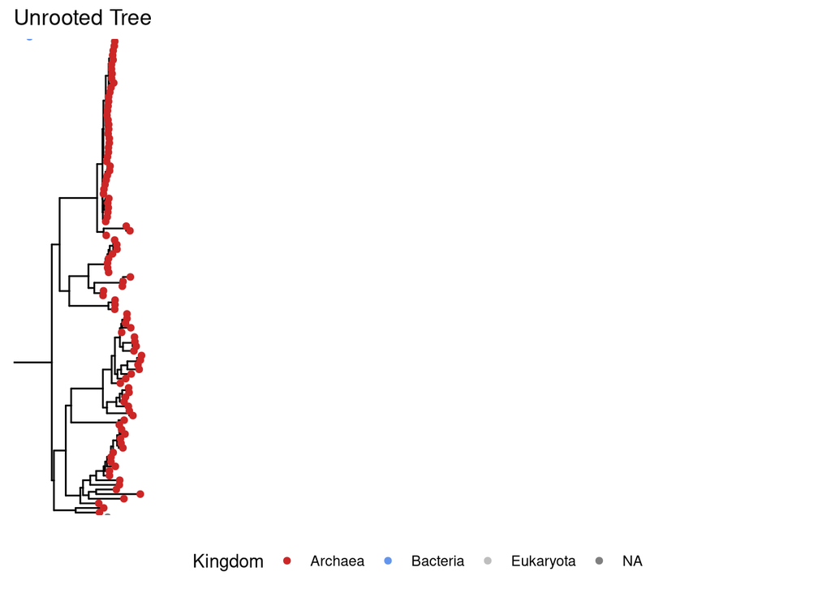

```r
# View clade to check it out
viewClade(kingdom_tree, archaeal_node)
```

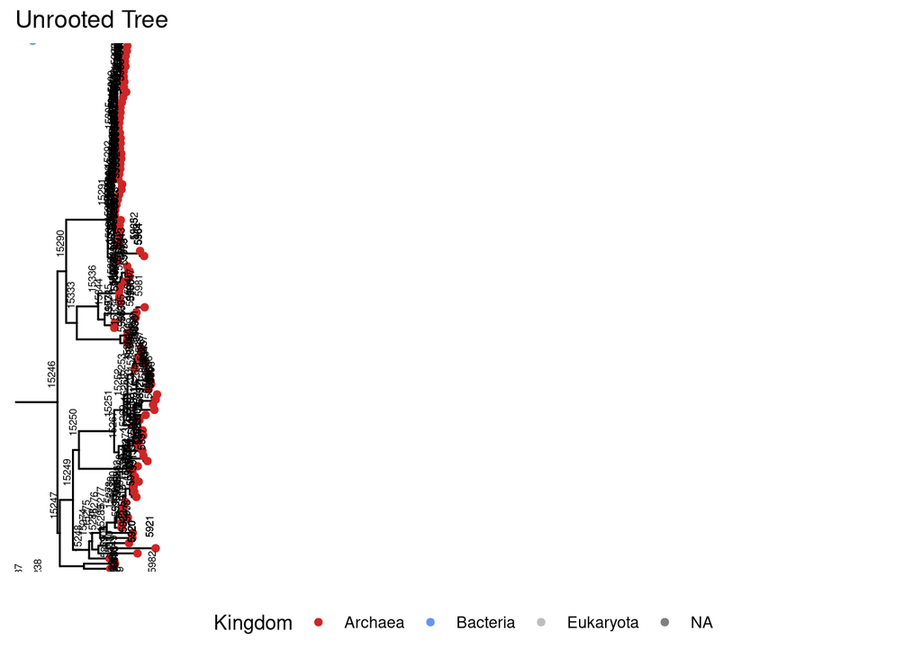

```r
viewClade(kingdom_node_tree, archaeal_node)
```

[figure not shown]

```r
# Let's highlight!
node_15246 <-
  ggtree(unrooted_physeq_rm16517) +
  geom_tippoint(mapping = aes(color = Kingdom), size = 1.5) +
  #geom_text(aes(label = node), hjust = -0.7, vjust = -0.2, size = 2) +
  geom_highlight(node = archaeal_node, fill = "goldenrod1") +
  scale_color_manual(values = c("firebrick3", "cornflowerblue", "grey"))

# Visualize it
node_15246
```

```r
# Root it!
archaeal_rooted_tree <-
  ape::root(phy_tree(unrooted_physeq_rm16517),
            node = archaeal_node, resolve.root = TRUE)
archaeal_rooted_noEuktree <-
  archaeal_rooted_tree %>%
  pop_taxa(., eukaryota_ASVs)

# Check it!
tidytree::is.rooted(archaeal_rooted_tree)
```

```
## [1] TRUE
```

Great, we have successfully rooted the tree! Now, let’s plot it to also confirm this visually.